# Data sleuthing with #citizensleuth

This page contains R code used to compile a plot of the total disclosures declared by the White House staff in their form 278e.  
The data came from the Center for Public Integrity: https://www.publicintegrity.org/citizensleuth

The goal of this exercise was to estimate and visualize the incomes of civil servants in the current administration.

This work is based on official, publicly available data. However, it does not constitute in itself an official document. Any mistakes are the responsibility of the author alone.

The full analysis code is presented in this webpage. Please address comments or corrections by emailing me: bart.burak@gmail.com Scroll down to skip the code and go straight to the final plot.

## Technical info:

The code is written for the R analysis software. It was written with markdown and compiled using knitr. In addition, for this code to work I need to load the following R packages:  
-readxl  
-ggrepel  
-dplyr  
-scales  
-stringr

## Read in the data:

This is a google doc that can be downloaded from: https://docs.google.com/spreadsheets/d/1R5AOpTBa6kro2qbSRa7kUD-Gg2FKD7v6vc2EJS7Dooo/edit#gid=1990489212

```r
sheet4 <- read_excel("data/TRUMP ADMINISTRATION PERSONAL FINANCES_ SEARCHABLE SPREADSHEETS.xlsx", sheet=4)
```

## Clean up the data

```r
d <- sheet4
d$amt <- d$`AMOUNT OF INCOME`
# replace the "none or less than $200" occurences by $100, and NAs by
d$amt[grep("None",d$amt)] = 100
d$amt[is.na(d$amt)] = 0
d$amt[d$amt=='$'] = 0


# Remove commas, spaces, dollar signs, parentheses
d$amt <- gsub(",","",d$amt)
d$amt <- gsub(" ","",d$amt)
d$amt <- gsub("\\$","",d$amt)
d$amt <- gsub(")","",d$amt)

# Remove the word "Over"
# Note: this means that those who answered "Over 5,000,000" are only assigned "5,000,000"
d$amt <- gsub("Over","",d$amt)

# Some people gave two answers on the same line - this code splits them into two cells:
d$amt1 <- gsub(";.*$","",d$amt)
d$amt2 <- 0
d$amt2[grep(";",d$amt)]<- gsub("^.*;","",d$amt[grep(";",d$amt)])


# Many people answered with a range (ex: 201-1000) - this code replace all ranges with the midpoint (ex: '201-1000' becomes '600.5'):
d$rg_low <- as.numeric(gsub("-.*$","",d$amt1))
d$rg_high <- as.numeric(gsub("^.*-","",d$amt1))
d$mid <- (d$rg_low + d$rg_high)/2

# Calculate the total per line (for those who gave two answers on the same line):
d$totamt_perline = round(as.numeric(d$mid)+as.numeric(d$amt2),digits=0)

# Calculate the total per person:
totInc<- aggregate(d$totamt_perline, list(name = d$NAME),FUN=sum, na.rm=TRUE)
names(totInc)[names(totInc) == 'x'] <- 'TotalIncome'
totInc<- mutate(totInc, Millions = TotalIncome/1000000)

# Replace first names with just the initial (for legibility on the graph):
totInc$nameInitial <- str_extract(totInc$name,"^.*, .")

# Rank the staff from richest to least-rich:
totInc$rank <-round(rank(-totInc$TotalIncome, na.last = TRUE),digits=0)
```

## Make the plot:

```r
# Select all the multi-millionaires (excluding Trump himself)
topWH <- filter(totInc, Millions >= 2 & rank >1)

# Make a caption:
caption <- "Notes: Reported ranges were approximated at midpoint (ex: '200-1000' was approximated by '600'). Donald J. Trump not included - he declared approximately 590 million. † indicates someone who no longer worked with the administration at the time the data was published."
caption <- paste0(strwrap(caption, 100), sep="", collapse="\n")

# Generate the plot: Millions disclosed against rank
g <- ggplot(topWH, aes(x=rank, y=Millions, size=Millions, label=nameInitial))
g <- g+geom_point() + ylab("Total Disclosure in Millions (approx)") + xlab("Ranking")
g <- g + geom_label_repel(size=2)
g <- g + theme(panel.background  = element_rect(fill = 'lightblue'),
               plot.background  = element_rect(fill = 'lightyellow2'),
               plot.caption=element_text(hjust = -0.1))
g <- g + labs(title = "Multimillion incomes in Trump's White House",
              subtitle = "(those who declared >2M on Form 278e: Public Financial Disclosure)",
              caption = caption)
g <- g + theme(plot.caption=element_text(size=8, hjust=0, margin=margin(t=5)))
```

# Final plot:

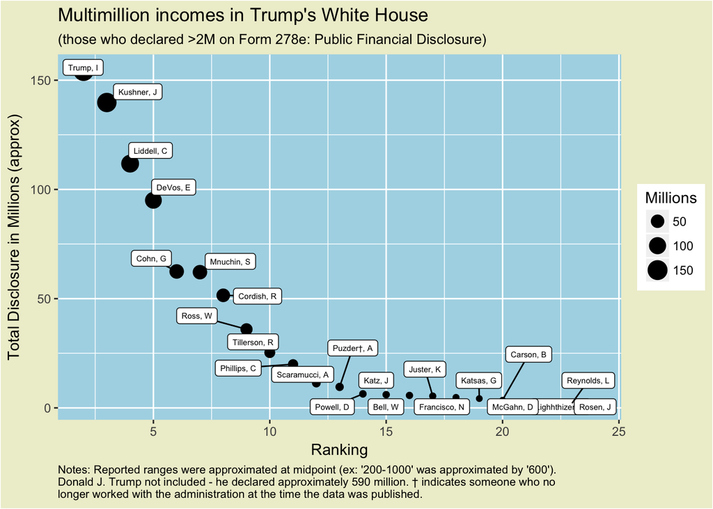

```r
g
```